# STAT 304: Final Project

Analyzing Student Retention at Roanoke College and Home Sales in Salem, VA

Selam Mekonnen

April 28, 2023

### Part 1: Student Retention at Roanoke College

The goal in the investigation of student retention at Roanoke College is to determine what impacts a student from being retained from the second to third year. Note that we only consider data from 2017 and 2018 since the data from 2019 is not available yet. We use the data frame rc.ret for the analysis.

| ID | Start.Term | First.Gen.No.Bach | First.Gen.No.Col | Pell.Grant |
| --- | --- | --- | --- | --- |
| 1 | 2017FA | Yes | No | No |
| 3 | 2017FA | No | No | No |
| 4 | 2017FA | Yes | No | No |
| 5 | 2017FA | No | No | No |
| 6 | 2017FA | No | No | No |
| 7 | 2017FA | No | No | No |

Creating a fitted model that explains third year retention by fall cumulative GPA and plotting the model.

Logistic Model Explaining 3rd Year Retention by Fall GPA

|  | Estimate | Std. Error | z value | Pr(>\|z\|) |
| --- | --- | --- | --- | --- |
| (Intercept) | -0.3058473 | 0.3416660 | -0.8951645 | 0.3706991 |
| Cum.GPA.Dec | 0.9217092 | 0.1324167 | 6.9606719 | 0.0000000 |

- Fall semester GPA has a significant positive effect on student retention to third year. Meaning, for every increase in Fall GPA, the odds of students returning for junior year increase by a factor of 2.52 at Roanoke College.
- Fitted Model: $\Large \pi= {\Large {\frac{e^{-0.31 + 0.92(Cum.GPA.Dec)}}{1 + {e^{-0.31 + 0.92(Cum.GPA.Dec)}}}}}$

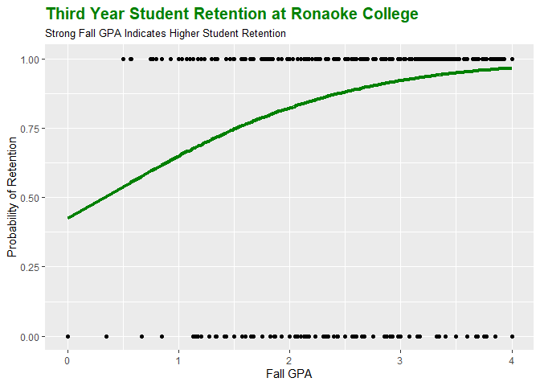

Adding the variable varsity sport into the model from previous analysis and graphing it to understand the relationship between third year retention and playing a varsity sport.

Logistic Model Explaining 3rd Year Retention By Fall GPA & Varsity Sport

|  | Estimate | Std. Error | z value | Pr(>\|z\|) |
| --- | --- | --- | --- | --- |
| (Intercept) | -0.3137278 | 0.3478803 | -0.9018268 | 0.3671489 |
| Cum.GPA.Dec | 0.9217724 | 0.1323743 | 6.9633775 | 0.0000000 |
| AthleteYes | 0.0318615 | 0.2670817 | 0.1192950 | 0.9050417 |

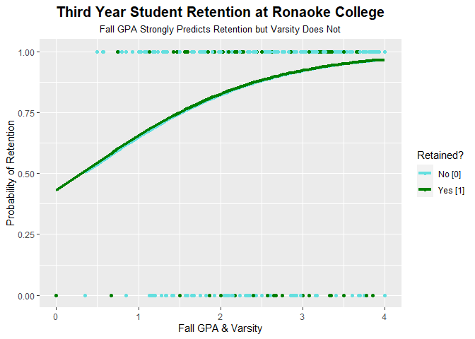

### Part 2: Salem Real Estate

The goal is to investigate the sale price of homes in Salem, VA during the years 2020, 2021, and 2022. The data frame ‘real’ contains all homes sold during that three year period.

| X | OBJECTID | PID | tax_map_number | street_number |
| --- | --- | --- | --- | --- |
| 1 | 24 | 25 | 10-1-5.2 | 353 |
| 2 | 29 | 30 | 10-1-5.7 | 312 |
| 3 | 33 | 34 | 10/3/2001 | 380 |
| 4 | 46 | 48 | 100-2-15 | 1614 |
| 5 | 72 | 74 | 100-3-2 | 1827 |
| 6 | 74 | 76 | 100-3-4 | 415 |

|  | Estimate | Std. Error | t value | Pr(>\|t\|) |
| --- | --- | --- | --- | --- |
| (Intercept) | 14465.7505 | 6201.189760 | 2.332738 | 0.0198274 |
| sqft_of_main | 134.4636 | 3.055037 | 44.013749 | 0.0000000 |
| as.factor(year_sold)2021 | 11195.1853 | 5119.771040 | 2.186657 | 0.0289611 |
| as.factor(year_sold)2022 | 39102.0242 | 5343.847597 | 7.317204 | 0.0000000 |

- Fitted Model: $\hat{Y}= {14465.75 + 134.46(sqft_ofmain) + 11195.19(year_sol_d2021) + 39102.02(year_sol_d2022)}$

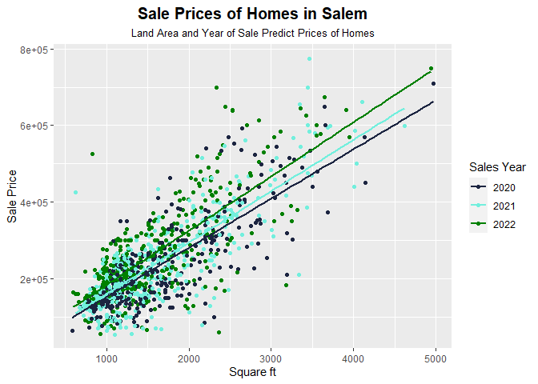

To look at the relationship of these variables on a deeper level, we will use different kinds of models and find a model that describes it most accurately.

| sale_price | year_sold | size_of_main_land | total_assessment | sqft_of_main |
| --- | --- | --- | --- | --- |
| 478000 | 2021 | 29229 | 429700 | 2046 |
| 515000 | 2021 | 28270 | 424500 | 2158 |
| 451000 | 2021 | 19820 | 366500 | 2614 |
| 406000 | 2022 | 15750 | 254300 | 1990 |
| 184000 | 2021 | 22216 | 161500 | 1000 |
| 154950 | 2021 | 21649 | 147900 | 1427 |

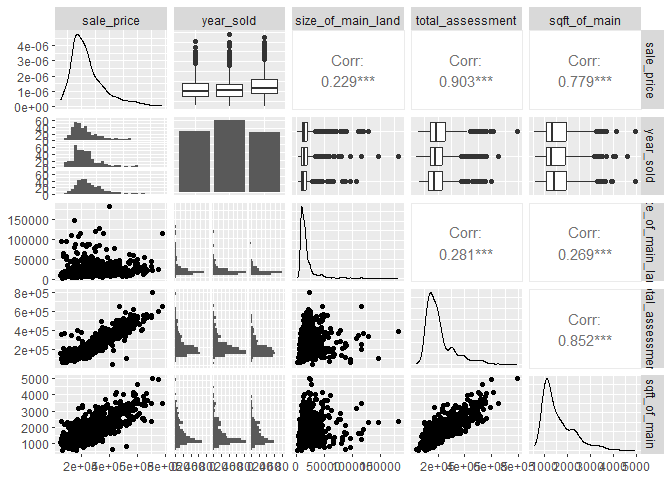

**Residual Plots for Full Model**

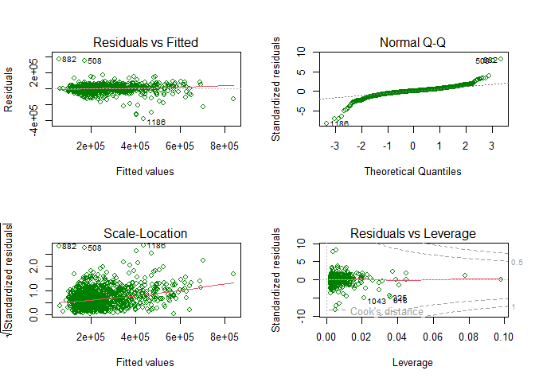

**Checking Assumption Violations**

**Backward Fitting with OLS**

```
## Start:  AIC=25753.7
## sale_price ~ year_sold + size_of_main_land + total_assessment +
##     sqft_of_main
##
##                     Df  Sum of Sq        RSS   AIC
## - sqft_of_main       1 1.2965e+06 2.5071e+12 25747
## - size_of_main_land  1 5.7990e+09 2.5129e+12 25749
## <none>                            2.5071e+12 25754
## - year_sold          2 6.4380e+11 3.1509e+12 26013
## - total_assessment   1 3.8884e+12 6.3955e+12 26869
##
## Step:  AIC=25746.61
## sale_price ~ year_sold + size_of_main_land + total_assessment
##
##                     Df  Sum of Sq        RSS   AIC
## - size_of_main_land  1 5.8112e+09 2.5129e+12 25742
## <none>                            2.5071e+12 25747
## - year_sold          2 6.5193e+11 3.1590e+12 26009
## - total_assessment   1 1.3342e+13 1.5850e+13 27949
##
## Step:  AIC=25742.3
## sale_price ~ year_sold + total_assessment
##
##                    Df  Sum of Sq        RSS   AIC
## <none>                           2.5129e+12 25742
## - year_sold         2 6.5755e+11 3.1705e+12 26007
## - total_assessment  1 1.4294e+13 1.6807e+13 28012
```

|  | Estimate | Std. Error | t value | Pr(>\|t\|) |
| --- | --- | --- | --- | --- |
| (Intercept) | -1415.471434 | 3678.8395397 | -0.3847603 | 0.7004835 |
| year_sold2021 | 17507.097153 | 3208.1469430 | 5.4570746 | 0.0000001 |
| year_sold2022 | 57732.705859 | 3356.1714104 | 17.2019539 | 0.0000000 |
| total_assessment | 1.059513 | 0.0128564 | 82.4112585 | 0.0000000 |

**Forward Fitting with OLS**

```
## Start:  AIC=28012.87
## sale_price ~ 1
##
##                     Df  Sum of Sq        RSS   AIC
## + total_assessment   1 1.3924e+13 3.1705e+12 25996
## + sqft_of_main       1 1.0379e+13 6.7150e+12 26896
## + size_of_main_land  1 8.9506e+11 1.6199e+13 27950
## + year_sold          2 2.8756e+11 1.6807e+13 27997
## <none>                            1.7094e+13 28013
##
## Step:  AIC=25996.4
## sale_price ~ total_assessment
##
##                     Df  Sum of Sq        RSS   AIC
## + year_sold          2 6.5755e+11 2.5129e+12 25722
## + size_of_main_land  1 1.1435e+10 3.1590e+12 25994
## + sqft_of_main       1 7.0126e+09 3.1635e+12 25996
## <none>                            3.1705e+12 25996
##
## Step:  AIC=25721.94
## sale_price ~ total_assessment + year_sold
##
##                     Df  Sum of Sq        RSS   AIC
## + size_of_main_land  1 5811179575 2.5071e+12 25721
## <none>                            2.5129e+12 25722
## + sqft_of_main       1   13496892 2.5129e+12 25724
##
## Step:  AIC=25721.17
## sale_price ~ total_assessment + year_sold + size_of_main_land
##
##                Df Sum of Sq        RSS   AIC
## <none>                      2.5071e+12 25721
## + sqft_of_main  1   1296544 2.5071e+12 25723
```

|  | Estimate | Std. Error | t value | Pr(>\|t\|) |
| --- | --- | --- | --- | --- |
| (Intercept) | -136.6783414 | 3755.6978185 | -0.0363923 | 0.9709757 |
| total_assessment | 1.0656994 | 0.0133747 | 79.6802312 | 0.0000000 |
| year_sold2021 | 17497.4579178 | 3205.7833279 | 5.4580912 | 0.0000001 |
| year_sold2022 | 57540.0280555 | 3355.6942691 | 17.1469817 | 0.0000000 |
| size_of_main_land | -0.1464853 | 0.0880905 | -1.6628964 | 0.0965958 |

- I used OLS by employing AIC and BIC models to determine the most effective approach for my data. I did not have a categorical response variable thus I did not need to use logistic models like lasso or ridge regression, and the predictor variables consisted of both continuous and categorical data which makes the data complex.
- To ensure the accuracy of the models, I first checked for assumption violations that might impact the results. Both AIC and BIC gave similar models, however, since having a model that is less complex is best in most cases, I went with the decision of using BIC as my final model.
- Fitted Model using BIC: $\hat{Y}= {-1415 + 17510(year_sold2021) + 57730(year_sold2022) + 1.060(total_assessment )}$

| R-squared |
| --- |
| 0.8529963 |

To check the accuracy of my BIC model, I will estimate the sale price of 427 N Market St and compare it to the actual price of the home in order to analyze how well the model can predict the sale prices. Data frame ‘sold_home.csv’ is used for the analysis. (See actual prices on Zillow following the URL: https://www.zillow.com/homedetails/427-N-Market-St-Salem-VA-24153/79271083_zpid/)

- My model was good at estimating the sale price of 427 N Market St. The actual sale price was $\$$`483,300` while my model estimated the price to be $\$$`456,919.2`. There are various reasons why a predicted outcome may differ from the actual. One potential factor is the choice of model, as different models can produce varying degrees of accuracy. Additionally, issues such as underfitting/overfitting can impact a model’s ability to accurately predict. And another factor could be the case of missing values which can also contribute to differences between the predicted and actual results.